# UkBioBank Gout Summary Report

Murray Cadzow

2016-03-07

# Total UkBioBank

\pagebreak

## Gout Numbers

There are `7961` total posssible gout cases and `404935` total potential controls from a total dataset of `502655` people. Of the gout cases, there are:

- `6811` self reported cases
- `1197` cases with either a primary or secondary hospital diagnosis (using ICD-10)
- `6027` cases as defined by the Winnard et al 2012 criteria (hospital diagnosis or on gout drugs)

### Excluded

- `2229` people excluded due to hospital criteria
- `53` people excluded based on medication
- `53` met exclusion criteria for both hospital and medication.

`4565` people had renal disease

### Hospital Diagnosis

Of the `1197` people who had a hospital diagnosis for gout recorded, `752` also self reported having gout

- `692` are on gout related drugs
- `672` are on urate lowering therapy

### Drugs:

There were `5522` people on gout related drugs (Allopurinol, Colchicine, Febuxostat, and Sulphinpyrazone) of these, `5379` were on urate lowering therapy (Allopurinol, Febuxostat, and Sulphinpyrazone)

### Self Report

Of the `6811` self reported cases:

- `752` people had a hospital diagnosis
- `4877` people met the winnard criteria
- `4736` people were on gout related drugs, and
- `4638` people were explicitly on urate lowering therapy

Overall, there were `4877` people who self reported and also met another gout criteria, leaving only `1934` people who are dignosed as having gout solely by self reporting.

### Sex

```
##              Female   Male
## total        273472 229183
## totalaff     217585 195311
## totalgout       678   7283
## totalcontrol 217585 195311
## self            499   6312
## winnard         516   5511
## winnard_self    678   7283
## hosp            129   1068
## ult             412   4967
## drug            434   5088
## self_ult        595   6957
```

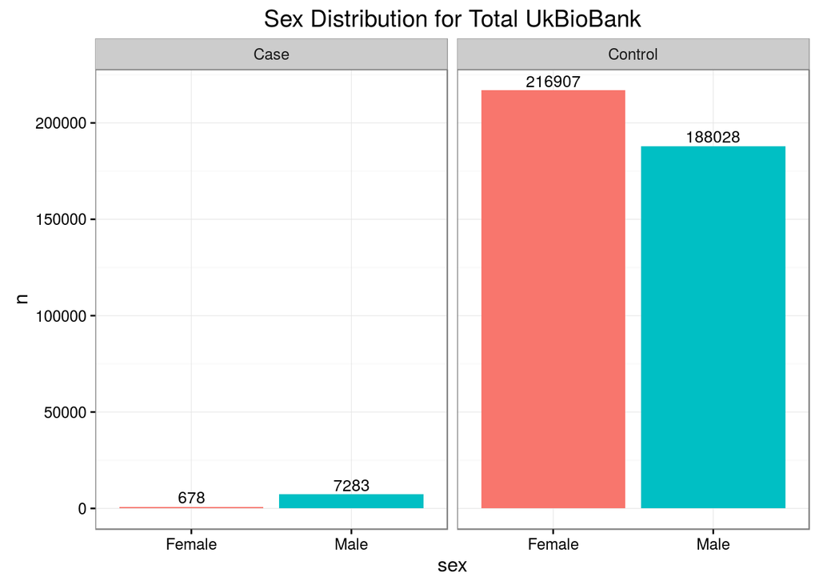

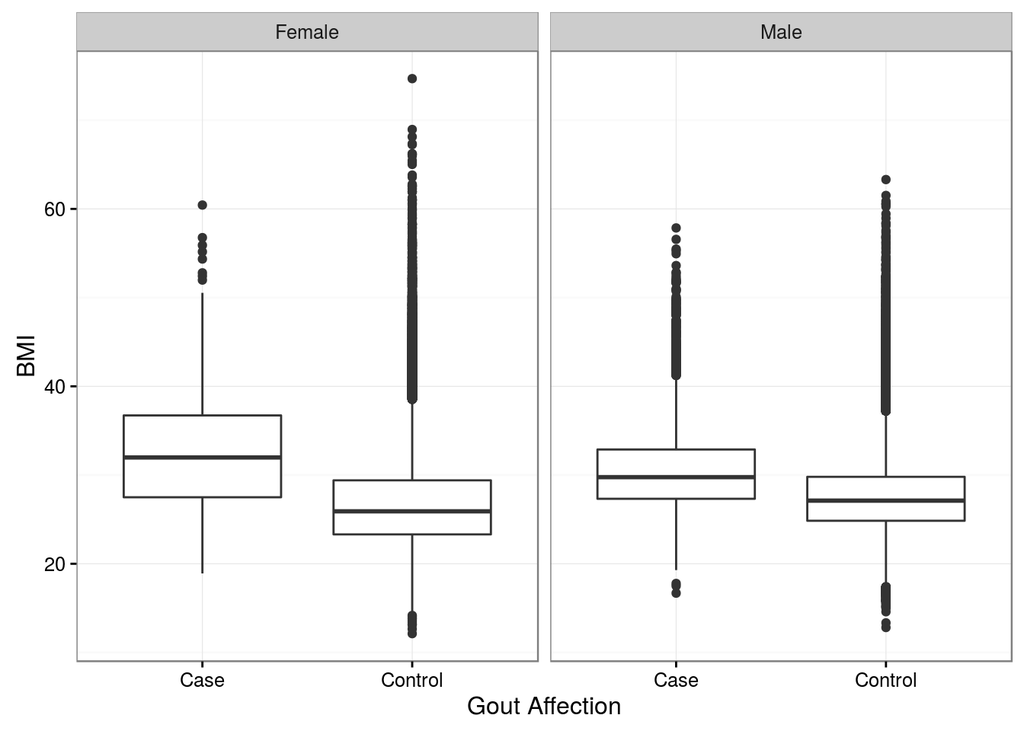

BMI Summary:

[output not shown]

# Genotyped

There are a total of `152249` people with genotypes

## All

For the GWAS based on all gout criteria there were `2412` cases and `7522` controls, for a total sample size of `9934`

There were:

- `1137` people on diuretics
- `1633` people taking allopurinol
- `0` people taking febuxostat
- `9` people taking sulphinpyrazone
- `63` people taking cochicine

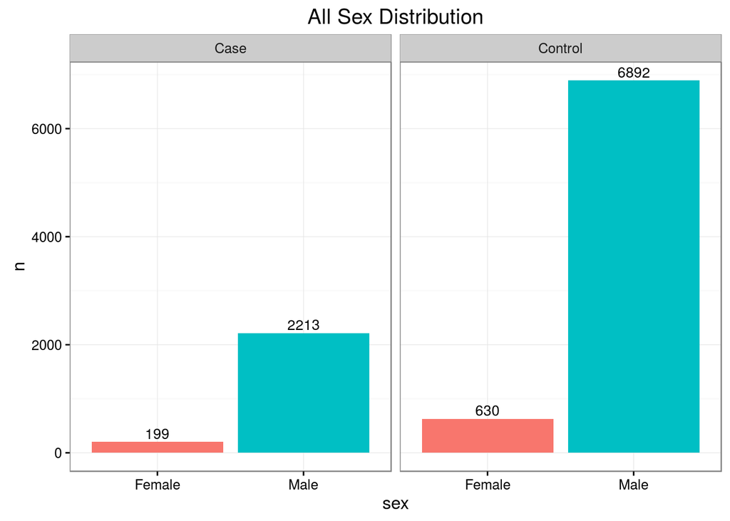

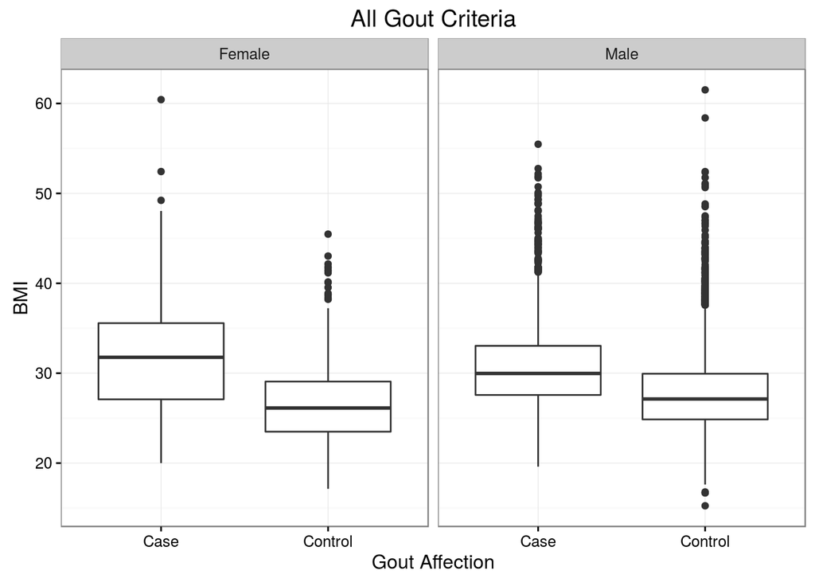

BMI Summary:

```
##        cc    sex     mean       sd     min  median     max
## 1    Case Female 32.13685 6.469754 20.0030 31.7688 60.4321
## 2    Case   Male 30.70038 4.708405 19.6052 29.9730 55.4699
## 3 Control Female 26.81730 4.609012 17.1376 26.1286 45.4687
## 4 Control   Male 27.74571 4.279707 15.2526 27.1349 61.5149
```

## Winnard

For the GWAS based on all gout criteria there were `1841` cases and `5734` controls, for a total sample size of `7575`

There were:

- `911` people on diuretics
- `1629` people taking allopurinol
- `0` people taking febuxostat
- `9` people taking sulphinpyrazone
- `63` people taking cochicine

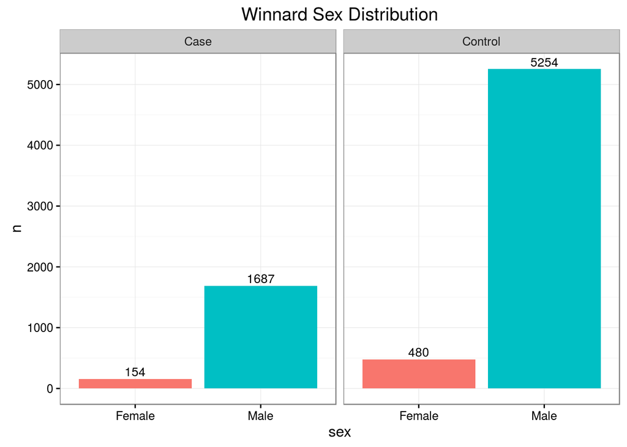

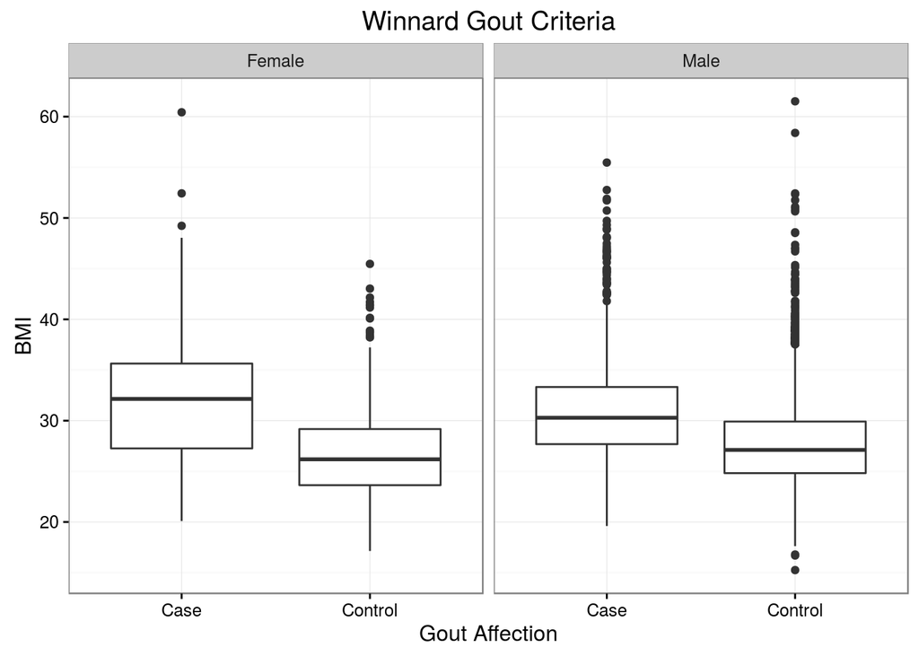

BMI Summary:

```
##        cc    sex     mean       sd     min  median     max
## 1    Case Female 32.26547 6.380062 20.0973 32.1427 60.4321
## 2    Case   Male 30.92492 4.737534 19.6052 30.2841 55.4699
## 3 Control Female 26.88370 4.704808 17.1376 26.1859 45.4687
## 4 Control   Male 27.72779 4.286627 15.2526 27.1106 61.5149
```